# Session 6

## Regular Expressions

### Character classes

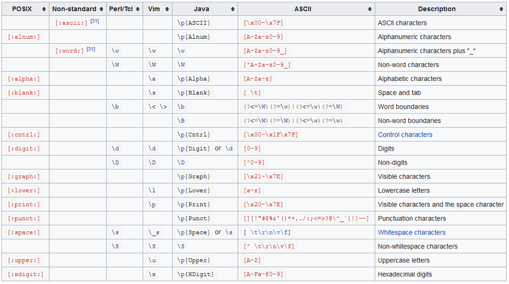

R supports POSIX, Perl-like, and ASCII expressions

Source: [wikipedia](https://en.wikipedia.org/wiki/Regular_expression)

## Regular Expressions

### Character classes – Example

```r
# Example: Remove Numbers
chr <- "RWorkshop2021@ufl.edu"
gsub("[[:digit:]]", "",chr)
gsub("\\d", "",chr)
gsub("[0-9]", "",chr)
```

```r
# Example: Alphabet
gsub("[[:alpha:]]", "",chr)
gsub("[A-Za-z]", "",chr)
```

## Regular Expressions

### List of Metacharacters – Single character match

| Metacharacter | Matches |
| --- | --- |
| **.** | Matches any one character |
| […] | Matches any one character listed inside [] |
| [^…] | Matches any one character NOT listed inside [] |
| \*char* | Escape character. When char is a metacharacter, add \ to match liternal *char* |

```r
# Example
gsub("[a-c]", "", "banan.")
gsub("[^a-c]", "", "banan")
gsub("a.", "", "banana")
```

```r
# example
gsub(".", "", "...banana", perl=T)  # Need to Escape!
gsub("\\.", "", "...banana", perl=T)
```

## Regular Expressions

### List of Metacharacters – Quantifiers

| Metacharacter | Matches |
| --- | --- |
| ? | 0 or 1 |
| * | Any number including 0 |
| + | At least one |
| {min, max} | Min required, Max optional |

```r
# Example
chr=c("ggle", "gogle", "google", "gooogle", "goooogle")
grep("go?gle", chr, value=T)
grep("go*gle", chr, value=T)
grep("go+gle", chr, value=T)
grep("go{2,}gle", chr, value=T)
grep("go{1,3}gle", chr, value=T)
```

## Regular Expressions

### List of Metacharacters – Position Matching

| Metacharacter | Matches |
| --- | --- |
| ^ | Matches the position at the start of the line |
| $ | Matches the position at the end of the line |
| \b | Matches the empty string at either edge of a word |
| \B | Matches the string that is not at an edge of a word |
| \< | Matches the position at the start of a word |
| \> | Matches the position at the end of a word |

```r
# Example
gsub("a", "A", "An anaconda living in the amazon area")
gsub("^a", "A", "An anaconda living in the amazon area")
gsub("a$", "A", "An anaconda living in the amazon area")
gsub("\\<a", "A", "An anaconda living in the amazon area")
gsub("a\\>", "A", "An anaconda living in the amazon area")
gsub("\\ba", "A", "An anaconda living in the amazon area")
gsub("\\Ba", "A", "An anaconda living in the amazon area")
```

## Regular Expressions

### List of Metacharacters – Other

Metacharacter

Matches

|

"or"

(…)

1. Limits Scope and (2) Capture for the backreferences

\1, \2, …

Matches text within the parentheses

\s (cf. \S); \t

A single whitespace character; The tab character

\n

The new line character

```r
# Example
grep("ise", c("summarize", "summarise"), value=T)
grep("i(s|z)e", c("summarize", "summarise"), value=T)
gsub(".* (.*) but.*","\\1","I what \"this\" but not that")
gsub("\\s{2,}", " ", "  please   remove empty   whitespaces  ")
gsub("^ +| +$", "", "  please   remove empty   whitespaces  ")  # trimws()
cat("This is line1\nThis is line2\n\tThis is a tab")
```

## Regular Expressions

### Your Turn

1. Is this a valid price?

```r
is_price=c("$100", "$10.7", "$.99", "10", "$7,77", "$9.999")
# Only return $100, $10.7, $.99
```

2. Return price

```r
chr = "I've bought 6-pack beer on sale for 4.99 dollars"
# Return 4.99
```

## Regular Expressions

### Your Turn – Amazon Data

```r
# Read the data
df<-read.csv("data/thermostat_amazon.csv", stringsAsFactors = F)
```

1. Change the "star" column to integer value only

"1.0 out of 5 stars" -> 1

2. Create three columns – "year", "month", "day"  
   Assign values based on the "date" column
3. Create a new column "verified"  
   Assign 1 if column "info_2" contains "Verified Purchase"  
   0 o.w.

## Regular Expressions

### Your Turn – Amazon Data

4. Clean reviews (column: info_3)

   Reduce punctuation repeating more than 2 consecutive times to once

```r
# Example
df$info_3[2]; df$info_3[4]; df$info_3[8];
```

5. More cleanings to consider…

Spelling Errors

Abbreviations

Punctuations

Lower/Upper Cases

Emoji

Encoding issues